# Project 3 - Loan

Hye Young Park

June 30th, 2019

Source: https://www.kaggle.com/wendykan/lending-club-loan-data

Here is data regarding loans issued from “lending-club-loan-data”. We are interested in seeing if the loan amount is affected by annual income, and if so, how?

```r
library(dplyr)
```

```r
library(package = "lattice")
library(ggplot2)
```

## 1. Formulate your question

Following the EDA checklist, lets formulate our question. Does annual income affect the size of the loan amount funded?

## 2. Read in your data

```r
loan<-read.csv("C:/Users/illya/Downloads/loan.csv")
```

## 3. Check the packaging

```r
nrow(loan)
```

```
## [1] 9998
```

```r
ncol(loan)
```

```
## [1] 20
```

## 4. Run str()

```r
str(loan)
```

```
## 'data.frame':    9998 obs. of  20 variables:
##  $ loan_amnt          : int  25000 40000 11000 40000 34800 34525 10000 9000 40000 25000 ...
##  $ funded_amnt        : int  25000 40000 11000 40000 34800 34525 10000 9000 40000 25000 ...
##  $ funded_amnt_inv    : int  25000 40000 11000 40000 34800 34525 10000 9000 40000 25000 ...
##  $ term               : Factor w/ 2 levels " 36 months"," 60 months": 1 2 1 2 1 1 1 1 1 1 ...
##  $ int_rate           : num  6.46 10.33 8.19 10.72 8.19 ...
##  $ installment        : num  766 856 346 864 1094 ...
##  $ grade              : Factor w/ 7 levels "A","B","C","D",..: 1 2 1 2 1 2 3 1 2 5 ...
##  $ sub_grade          : Factor w/ 29 levels "A1","A2","A3",..: 1 6 4 7 4 7 12 5 7 25 ...
##  $ emp_title          : Factor w/ 5281 levels ""," Accountant",..: 3499 694 5097 719 1 3555 1368 3328 3462 1840 ...
##  $ emp_length         : Factor w/ 12 levels "< 1 year","1 year",..: 3 3 6 3 1 3 6 3 3 3 ...
##  $ home_ownership     : Factor w/ 4 levels "ANY","MORTGAGE",..: 2 2 2 2 2 2 3 2 2 2 ...
##  $ annual_inc         : num  1350002 1123100 1120000 1100000 1000000 ...
##  $ verification_status: Factor w/ 3 levels "Not Verified",..: 2 2 2 3 3 3 2 2 2 3 ...
##  $ issue_d            : Factor w/ 1 level "18-Dec": 1 1 1 1 1 1 1 1 1 1 ...
##  $ loan_status        : Factor w/ 6 levels "Charged Off",..: 2 2 2 2 2 2 2 2 2 2 ...
##  $ pymnt_plan         : Factor w/ 1 level "n": 1 1 1 1 1 1 1 1 1 1 ...
##  $ title              : Factor w/ 12 levels "Business","Car financing",..: 4 4 3 4 4 4 3 4 10 6 ...
##  $ zip_code           : Factor w/ 788 levels "010xx","011xx",..: 416 132 391 56 573 124 89 310 76 70 ...
##  $ addr_state         : Factor w/ 50 levels "AK","AL","AR",..: 22 38 15 31 3 38 34 2 34 31 ...
##  $ dti                : num  1.88 8.76 1.36 6.54 5.7 ...
```

## 5. Look at the top and the bottom of your data

```r
head(loan)
```

```
##   loan_amnt funded_amnt funded_amnt_inv       term int_rate installment
## 1     25000       25000           25000  36 months     6.46      765.77
## 2     40000       40000           40000  60 months    10.33      856.40
## 3     11000       11000           11000  36 months     8.19      345.67
## 4     40000       40000           40000  60 months    10.72      864.13
## 5     34800       34800           34800  36 months     8.19     1093.56
## 6     34525       34525           34525  36 months    10.72     1125.74
##   grade sub_grade          emp_title emp_length home_ownership annual_inc
## 1     A        A1 Plumber/Pipefitter  10+ years       MORTGAGE    1350002
## 2     B        B1                CEO  10+ years       MORTGAGE    1123100
## 3     A        A4      Utility clerk    4 years       MORTGAGE    1120000
## 4     B        B2      CFO Midstream  10+ years       MORTGAGE    1100000
## 5     A        A4                      < 1 year       MORTGAGE    1000000
## 6     B        B2          President  10+ years       MORTGAGE     900000
##   verification_status issue_d loan_status pymnt_plan
## 1     Source Verified  18-Dec     Current          n
## 2     Source Verified  18-Dec     Current          n
## 3     Source Verified  18-Dec     Current          n
## 4            Verified  18-Dec     Current          n
## 5            Verified  18-Dec     Current          n
## 6            Verified  18-Dec     Current          n
##                     title zip_code addr_state   dti
## 1      Debt consolidation    488xx         MI  1.88
## 2      Debt consolidation    160xx         PA  8.76
## 3 Credit card refinancing    463xx         IN  1.36
## 4      Debt consolidation    070xx         NJ  6.54
## 5      Debt consolidation    721xx         AR  5.70
## 6      Debt consolidation    152xx         PA 12.01
```

```r
tail(loan)
```

```
##      loan_amnt funded_amnt funded_amnt_inv       term int_rate installment
## 9993     30000       30000           30000  36 months    11.31      986.58
## 9994     40000       40000           40000  36 months    25.34     1597.60
## 9995     28800       28800           28800  60 months    20.89      777.36
## 9996      7000        7000            7000  36 months     7.56      217.94
## 9997     12000       12000           12000  36 months    11.80      397.43
## 9998     10000       10000           10000  60 months    15.02      238.01
##      grade sub_grade emp_title emp_length home_ownership annual_inc
## 9993     B        B3                  n/a       MORTGAGE          0
## 9994     E        E3                  n/a       MORTGAGE          0
## 9995     D        D4                  n/a       MORTGAGE          0
## 9996     A        A3                  n/a       MORTGAGE          0
## 9997     B        B4                  n/a           RENT          0
## 9998     C        C3                  n/a       MORTGAGE          0
##      verification_status issue_d loan_status pymnt_plan              title
## 9993     Source Verified  18-Dec     Current          n Debt consolidation
## 9994        Not Verified  18-Dec     Current          n Debt consolidation
## 9995        Not Verified  18-Dec     Current          n Debt consolidation
## 9996            Verified  18-Dec     Current          n              Other
## 9997        Not Verified  18-Dec     Current          n Debt consolidation
## 9998            Verified  18-Dec     Current          n Debt consolidation
##      zip_code addr_state dti
## 9993    374xx         TN  NA
## 9994    662xx         KS  NA
## 9995    853xx         AZ  NA
## 9996    958xx         CA  NA
## 9997    933xx         CA  NA
## 9998    335xx         FL  NA
```

## 6. Check your n’s (the count)

```r
#what loan amounts
table(loan$loan_amnt)
```

```
##
##  1000  1100  1200  1250  1300  1375  1400  1500  1550  1600  1650  1675
##    77     3    10     1     2     1     6    34     1    11     1     1
##  1700  1800  1850  1900  1925  1950  2000  2075  2100  2200  2300  2400
##     1    10     1     3     1     1    85     1     4    10     5    20
##  2500  2525  2600  2650  2700  2750  2800  2825  2850  2900  3000  3025
##    57     2     2     1     5     3    14     1     1     1   147     6
##  3075  3100  3125  3150  3200  3275  3300  3350  3375  3400  3450  3475
##     1     3     2     1    15     1     6     1     1     3     1     1
##  3500  3525  3600  3625  3700  3750  3775  3800  3900  4000  4050  4100
##    55     1    35     3     2     2     2     3     4   163     1     2
##  4150  4200  4225  4250  4300  4325  4400  4425  4500  4550  4575  4600
##     1    18     1     1     4     1    10     1    35     1     1     6
##  4625  4650  4675  4700  4750  4800  4850  4900  4950  5000  5100  5125
##     1     1     1     1     2    52     1     4     3   439     5     1
```

[output cut: 86 more lines]

```r
#how many different incomes?
select(loan, annual_inc) %>% unique %>% nrow
```

```
## [1] 1357
```

## 7. Validate with at least one external data source

```r
#check standards
summary(loan$annual_inc)
```

```
##    Min. 1st Qu.  Median    Mean 3rd Qu.    Max.
##       0   50000   70000   85377  101000 1350002
```

```r
#look at deciles of the data
quantile(loan$annual_inc, seq(0, 1, 0.1))
```

```
##        0%       10%       20%       30%       40%       50%       60%
##       0.0   35000.0   45000.0   53763.3   61000.0   70000.0   80000.0
##       70%       80%       90%      100%
##   95000.0  115000.0  150000.0 1350002.0
```

## 8. Try the easy solution first

```r
ranking <- group_by(loan, loan_amnt) %>%
  summarize(Median.Income = median(annual_inc)) %>%
  as.data.frame %>%
  arrange(desc(loan_amnt))
head(ranking,10)
```

```
##    loan_amnt Median.Income
## 1      40000        120000
## 2      39500        112500
## 3      39200         40000
## 4      39000        120660
## 5      38925        135800
## 6      38875        104805
## 7      38800        120000
## 8      38775        150000
## 9      38750        150000
## 10     38500         97000
```

```r
#one outlier (in terms of income) who took out a large loan
filter(loan, loan_amnt == 39200) %>% nrow
```

```
## [1] 1
```

```r
#number of people who took out the highest loan
filter(loan, loan_amnt == 40000) %>% nrow
```

```
## [1] 459
```

```r
tail(ranking,10)
```

```
##     loan_amnt Median.Income
## 591      1600         43000
## 592      1550         51464
## 593      1500         44622
## 594      1400         31000
## 595      1375         52000
## 596      1300         66898
## 597      1250         52000
## 598      1200         45500
## 599      1100         40000
## 600      1000         50000
```

## 9. Challenge your solution

Not necessary as easy solution was good enough for our purposes.

## 10. Follow up

We found that there was a tendency for people with larger incomes to take out larger loans in terms of amount.

## Ggplot 2 graphs and visualization

Next well look at some data regarding loan term and interest rates. This will show that people tend to take out smaller loans for shorter terms. We see that 50% of the people who took a 36 month loan had the Loan Amount < 10,000. We also see that no one who took out a 60 month loan took a loan that was < 10,000.

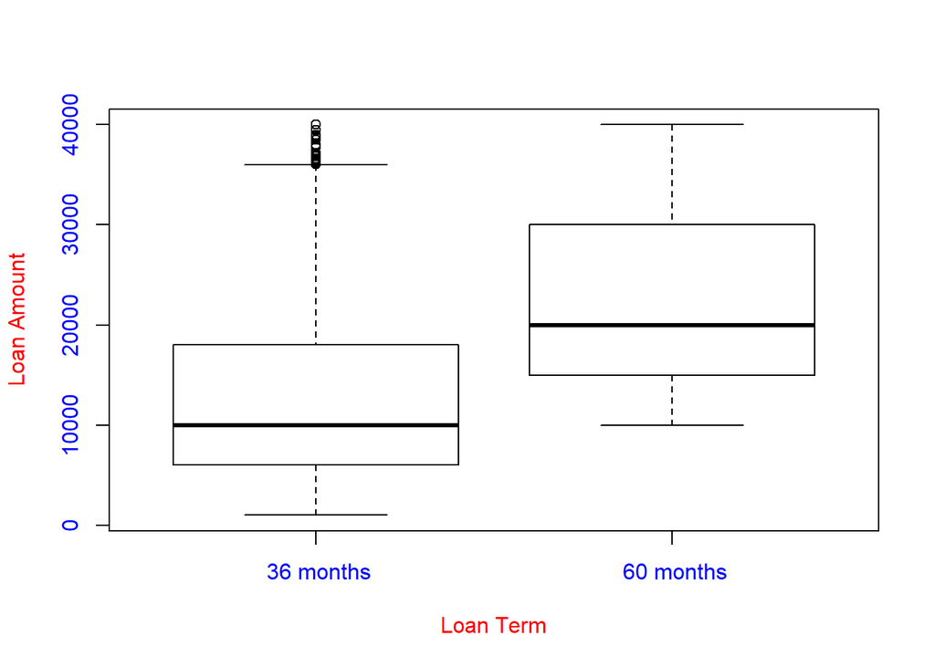

```r
boxplot(loan_amnt ~ term, loan, xlab="Loan Term", ylab="Loan Amount",col.axis="blue",col.lab="red")
```

Here we see a histogram of the annual income. Its skewed right so we use median as our measure of average income in the previous sections.

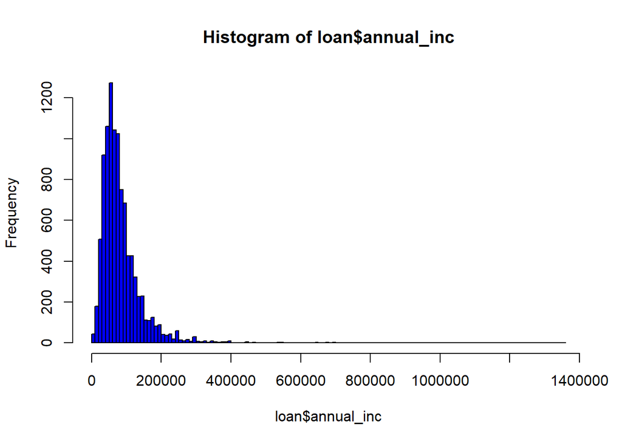

```r
hist(loan$annual_inc, breaks = 100, col = "blue")
```

Here is a fun plot showing the amount of loans by term.

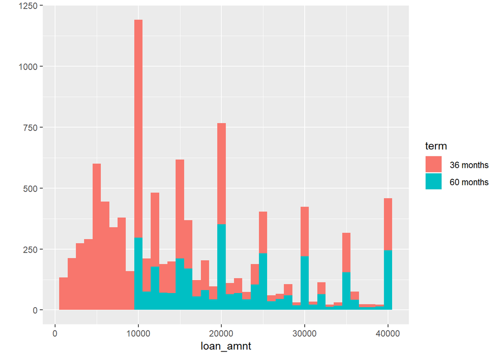

```r
qplot(loan_amnt, data = loan, binwidth=1000, fill = term)
```

Here are two graphs, one for each term. They show the histograms for the interest rate for each of the terms

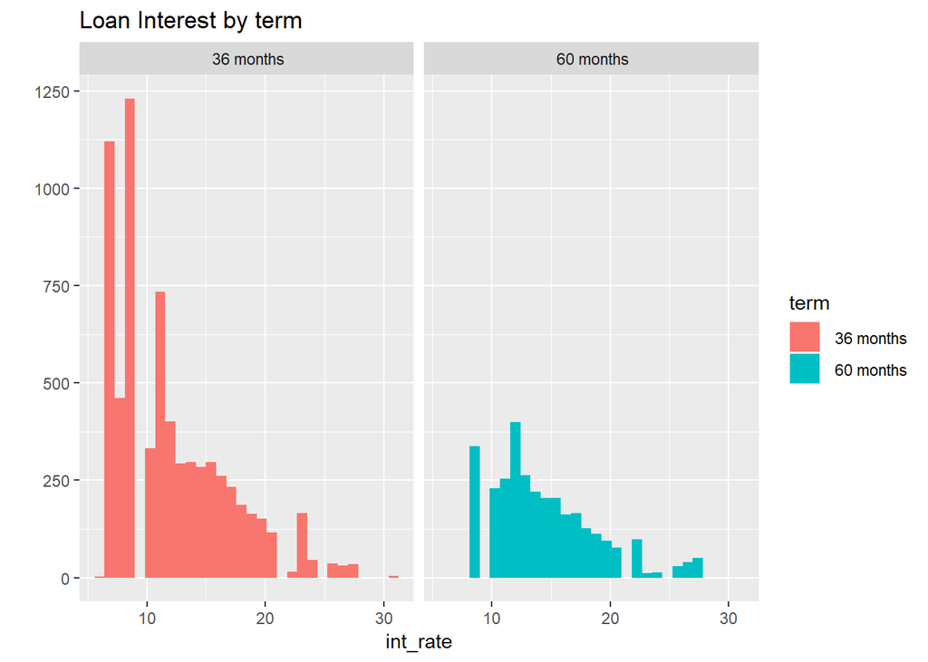

```r
qplot(int_rate, data = loan, facets = .~term, fill = term) + ggtitle("Loan Interest by term")
```

A simple bar chart of how many loans were taken out in each term.

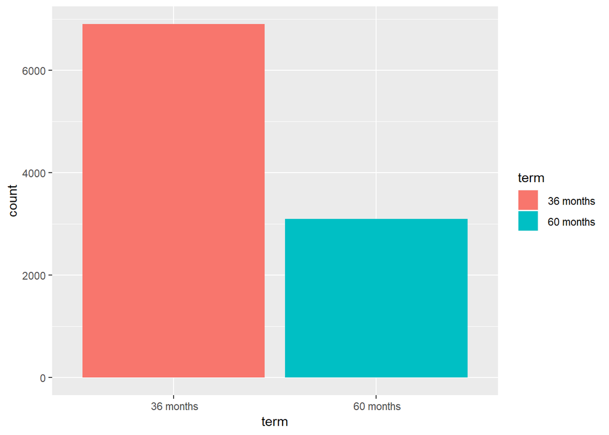

```r
ggplot(data = loan) +
  geom_bar(mapping = aes(x = term, fill= term))
```

—————— PROJECT 3 ——————

Null hypothesis - using categorical value “term” and quantitative variable “amount” I suspect it will be rejected due to variability between interest rates and incomes for the different loan terms. These are our data, loans with 36 month rates and loans with 60 month rates.

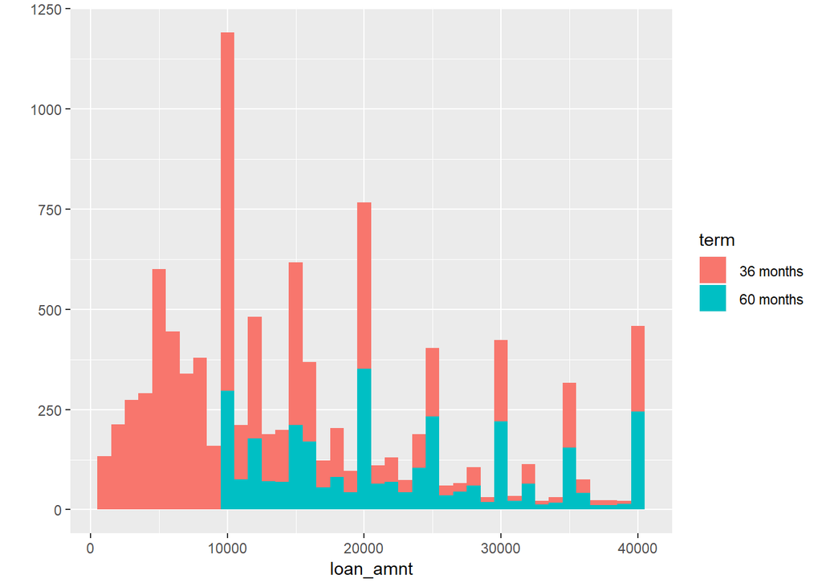

```r
qplot(loan_amnt, data = loan, binwidth=1000, fill = term)
```

```r
loan36 <- filter(loan, loan$term == " 36 months") ## get 36 month loans
thirtySixFiltered<-loan36[loan36$loan_amnt < 20000,] ##normalize data, get rid of outliers
loanLesstwenty <- sample_n(thirtySixFiltered, 3100)##match "n" of loan60
```

summary

```r
summary(loanLesstwenty$loan_amnt)
```

```
##    Min. 1st Qu.  Median    Mean 3rd Qu.    Max.
##    1000    5000    8500    8813   12000   19800
```

Standard Deviation

```r
sd(loanLesstwenty$loan_amnt)
```

```
## [1] 4467.077
```

a boxplot :)

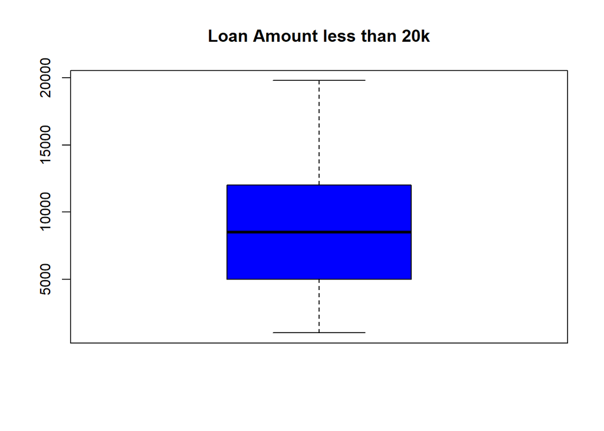

```r
boxplot(loanLesstwenty$loan_amnt, main = "Loan Amount less than 20k", col = "blue")
```

We do the same for the 60 month term loans.

```r
loan60 <- filter(loan, loan$term == " 60 months")
```

We don’t filter it since the data looks normal without many outliers.

Summary

```r
summary(loan60$loan_amnt)
```

```
##    Min. 1st Qu.  Median    Mean 3rd Qu.    Max.
##   10000   15000   20000   22352   30000   40000
```

standard deviation

```r
sd(loan60$loan_amnt)
```

```
## [1] 9117.195
```

boxplot

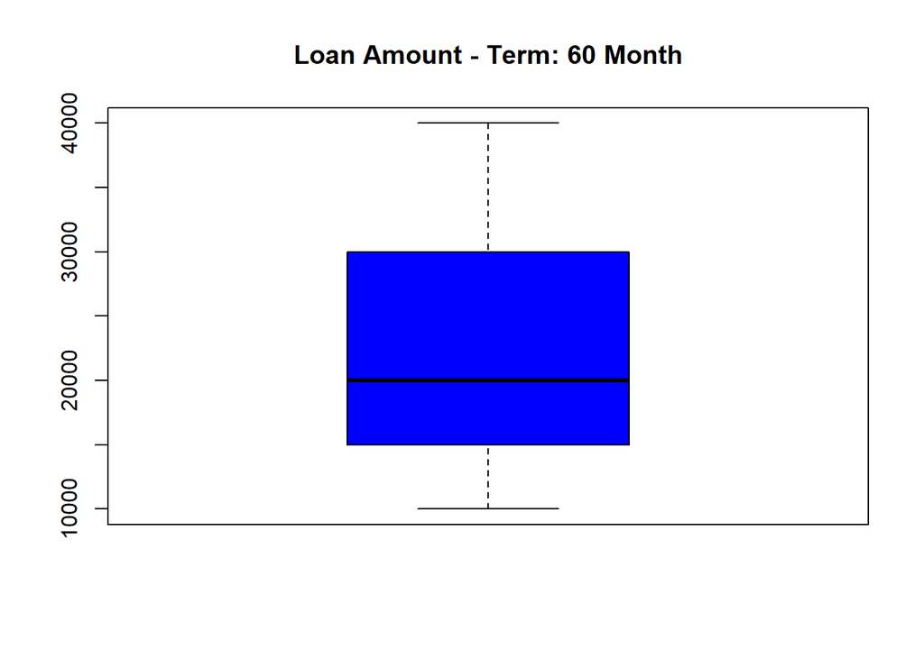

```r
boxplot(loan60$loan_amnt, main = "Loan Amount - Term: 60 Month", col = "blue")
```

```r
loanSixtyAmnt <- loan60$loan_amnt
loanThirtySixAmnt <- loanLesstwenty$loan_amnt
```

Next we run the t test on the resulting vectors, which will show us that we reject the null hypothesis, there IS a large difference in the means and I suspect that interest rate and annual income play a role in that.

```r
t.test(loanSixtyAmnt, loanThirtySixAmnt)
```

```
##
##  Welch Two Sample t-test
##
## data:  loanSixtyAmnt and loanThirtySixAmnt
## t = 74.227, df = 4502.3, p-value < 2.2e-16
## alternative hypothesis: true difference in means is not equal to 0
## 95 percent confidence interval:
##  13181.08 13896.25
## sample estimates:
## mean of x mean of y
## 22352.114  8813.452
```